# Loan Data Exploration

## Multivariate Exploration

The main thing I want to explore in this part of the analysis is how the three categorical measures of quality play into the relationship between Interest rate and Loan Amount.

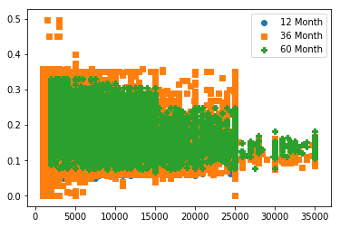

```python
##lets quickly overview the Numberic distribution with using multi variables .
Loan_Term = [[12, 'o'],
               [36, 's'],
              [60, 'P']]

for term, marker in Loan_Term:
    df_term = Loans[Loans['Term'] == term]
    plt.scatter(data = df_term, x = 'LoanOriginalAmount', y = 'BorrowerRate', marker = marker)
plt.legend(['12 Month','36 Month','60 Month']);
```

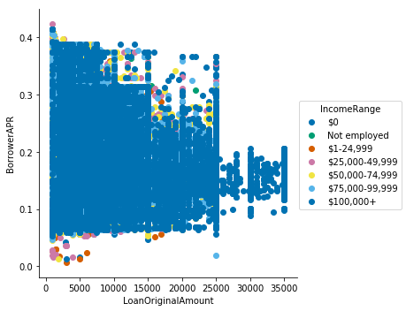

```python
#lets find another set of numarical distribution
g = sb.FacetGrid(data = Loans, hue = 'IncomeRange', size = 5,
                 palette = 'colorblind')
g.map(plt.scatter, 'LoanOriginalAmount', 'BorrowerAPR')
g.add_legend();
```

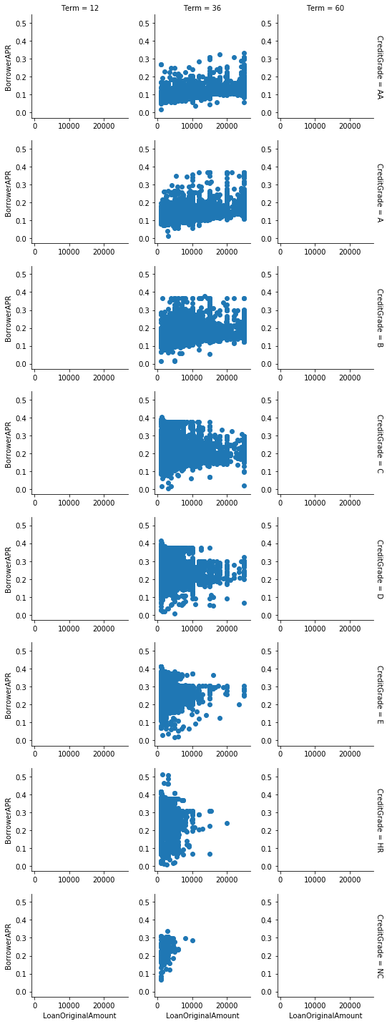

```python
##let check the relationshop with other categorical variables.
g = sb.FacetGrid(data = Loans, col = 'Term', row = 'CreditGrade', size = 2.5,
                margin_titles = True)
g.map(plt.scatter, 'LoanOriginalAmount', 'BorrowerAPR');
```

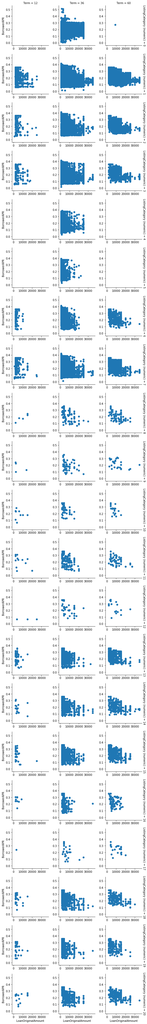

```python
g = sb.FacetGrid(data = Loans, col = 'Term', row = 'ListingCategory (numeric)', size = 2.5,
                margin_titles = True)
g.map(plt.scatter, 'LoanOriginalAmount', 'BorrowerAPR');
```

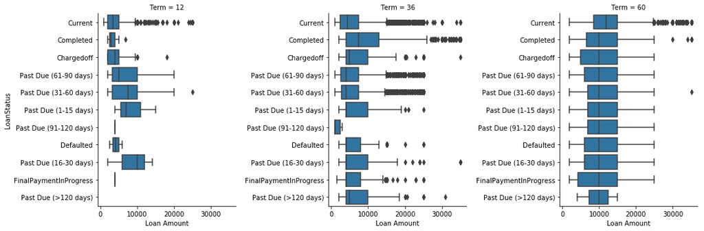

```python
## lets Quickly check the loan status with using box plot.
g = sb.FacetGrid(data = Loans, col = 'Term', size = 5,aspect =1)
g.map(sb.boxplot, 'LoanOriginalAmount', 'LoanStatus')
g.set_xlabels('Loan Amount')
g.set_ylabels('LoanStatus');
```

I tried looking at a interest rate variation by using faceted scatter map across categorical variable , but it seems like there's too many facets to look at. Perhaps a better summary like Multivariation cleary shows the interest rate varaion of each categorical variable.

one interesting observeation here ,if the income range 1Laks+ then they are getting more than 30K loans .Which is more interesting to find in Multi variation factor.

```python
## Let find the different over view like unsuccessful loan status statisitcs
Loans_filter = Loans.query('LoanStatus not in["Completed","Current"]')
Loans_filter.head()
```

|  | ListingKey | ListingNumber | ListingCreationDate | CreditGrade | Term | LoanStatus | ClosedDate | BorrowerAPR | BorrowerRate | LenderYield | ... | LP_GrossPrincipalLoss | LP_NetPrincipalLoss | LP_NonPrincipalRecoverypayments | PercentFunded | Recommendations | InvestmentFromFriendsCount | InvestmentFromFriendsAmount | Investors | category | Log_LoanAmount |
| --- | --- | --- | --- | --- | --- | --- | --- | --- | --- | --- | --- | --- | --- | --- | --- | --- | --- | --- | --- | --- | --- |
| 12 | 0F1A3597143888805163EF7 | 1081604 | 2013-12-15 20:01:10.757000000 | NaN | 36 | Past Due (1-15 days) | NaN | 0.17969 | 0.1435 | 0.1335 | ... | 0.00 | 0.00 | 0.00 | 1.0 | 0 | 0 | 0.0 | 1 | Debt Consolidation | 3.602060 |
| 15 | 0F483544120452347F48121 | 577164 | 2012-04-10 09:14:46.297000000 | NaN | 36 | Defaulted | 2012-12-19 00:00:00 | 0.35797 | 0.3177 | 0.3077 | ... | 3790.25 | 3790.25 | 0.00 | 1.0 | 0 | 0 | 0.0 | 10 | Household Expenses | 3.602060 |
| 17 | 0FDF336575182398852A8DC | 31540 | 2006-08-15 12:21:09.433000000 | AA | 36 | Chargedoff | 2008-05-22 00:00:00 | 0.13202 | 0.1250 | 0.1175 | ... | 6012.65 | 6012.67 | 268.96 | 1.0 | 0 | 0 | 0.0 | 85 | Not Available | 4.000000 |
| 23 | 101B35764008108187B2EBA | 758964 | 2013-04-22 13:29:19.073000000 | NaN | 36 | Defaulted | 2013-12-26 00:00:00 | 0.28032 | 0.2419 | 0.2319 | ... | 1882.27 | 1882.27 | 0.00 | 1.0 | 0 | 0 | 0.0 | 30 | Medical/Dental | 3.301030 |
| 42 | 10AD33803102786533722BB | 93263 | 2007-02-04 17:24:27.850000000 | HR | 36 | Chargedoff | 2008-08-08 00:00:00 | 0.30300 | 0.2900 | 0.2850 | ... | 1096.92 | 1096.92 | 0.00 | 1.0 | 0 | 0 | 0.0 | 15 | Not Available | 3.176091 |

5 rows × 83 columns

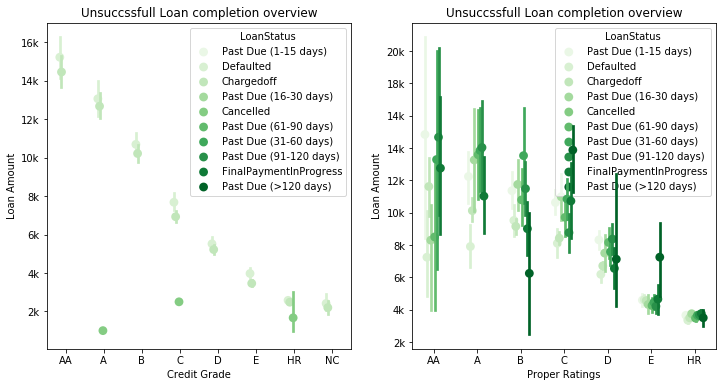

```python
fig, ax = plt.subplots(ncols = 2, figsize = [12,6])

sb.pointplot(data = Loans_filter, x = 'CreditGrade', y = 'LoanOriginalAmount', hue = 'LoanStatus',
             palette = 'Greens', linestyles = '', dodge = 0.4, ax = ax[0])
ax[0].set_title('Unsuccssfull Loan completion overview')
ax[0].set_ylabel('Loan Amount')
ax[0].set_xlabel('Credit Grade')
ax[0].set_yticks([2e3, 4e3, 6e3, 8e3,1e4,12e3,14e3,16e3])
ax[0].set_yticklabels(['2k','4k','6k', '8k', '10k','12k','14k','16k'])
ax[0].set_xticklabels([],minor = True)

sb.pointplot(data = Loans_filter, x = 'ProsperRating (Alpha)', y = 'LoanOriginalAmount', hue = 'LoanStatus',
             palette = 'Greens', linestyles = '', dodge = 0.4, ax = ax[1])
ax[1].set_title('Unsuccssfull Loan completion overview')
ax[1].set_ylabel('Loan Amount')
ax[1].set_xlabel('Proper Ratings')
ax[1].set_yticks([2e3, 4e3, 6e3,8e3,1e4,12e3,14e3,16e3,18e3,20e3])
ax[1].set_yticklabels(['2k','4k', '6k', '8k','10k','12k','14k','14k','18k','20k'])
ax[1].set_xticklabels([],minor = True)


plt.show();
```

Here looks like the average all the credit score lister has an issue with unsuccssful lons.One observation here is that Lowest rating people does get only samll amount from bank

### Talk about some of the relationships you observed in this part of the investigation. Were there features that strengthened each other in terms of looking at your feature(s) of interest?

I extended my investigation of interest rate defining against Loan Amount in this section by looking at the impact of the three categorical quality features. The multivariate exploration here showed that there indeed is a positive effect of Credit rating & Proper rating make impact interest rate, but in the dataset, this is initially hidden by the fact that higher Term were more getting interest ,

### Were there any interesting or surprising interactions between features?

now the multivaration clearly shows the two observeration.